# Grip strength, mating success, and immune function in US adults: a registered report

C. B. Smith and E. H. Hagen

03/23/2023

EHB Registered Report

1.4 Experimental aims and hypotheses

In a large, nationally representative US sample, we predict that hand grip strength will be significantly positively associated with male mating success but not female mating success. We also predict that there will be a negative association between male grip strength and white blood cell count, but no association between female grip strength and white blood cell count.

2. Exploratory analysis

In order to inform our hypotheses and refine our models, we first conducted exploratory analyses.

## Methods

To assess the relationship between strength and mating and immune outcomes we used data from the Centers for Disease Control (CDC) National Health and Nutrition Examination Survey (NHANES) from years 2011-2014. NHANES utilizes a complex, multi-stage sampling strategy in order to collect data representative of the civilian, non-institutionalized U.S. population. NHANES combines interview, examination, and laboratory data to assess health status and identify health risks for adults and children in the United States. Data collection occurs in new cycles every two years.

We will use data from years 2011-2014 since grip strength, our key predictor variable, was only collected in those years. We developed models based on previous research and through exploratory analyses of the 2011-2012 dataset to be tested in the 2013-2014 dataset which was held out pending in principle acceptance of this registered report. We include data from US adults between the ages of 18 and 60, the years when grip strength is the most stable . For each model, participants will be included if they have complete data for each predictor variable.

### Outcome variables:

In industrialized populations like the U.S., widespread access to contraceptives unlinks reproductive success from sexual behavior. Measures of mating success, including number of sexual partners and age at first sexual intercourse, are used as proxies as they are assumed to have been strongly correlated with reproductive success under ancestral conditions (Pérusse, 1993). Our main outcome variable was mating success, which we operationalized in three ways: 1) Total sexual partners was a count based on responses to the question: “In your lifetime, with how many men/women have you had any kind of sex?” 2) Total sexual partners in past year, from the question: “In the past 12 months, with how many men/women have you had any kind of sex?” Because of the way these questions are framed, (e.g. female participants were asked about their male partners and vice versa) these variables represent heterosexual partners (however, it is not necessarily the case that all of the participants included in these models identified as heterosexual). 3) Age at first sexual intercourse reported from: “How old were you when you had sex for the first time?” The sexual behavior questionnaire was self-administered on a computer in a private room at the examination center, using the Audio Computer Assisted Self Interview system, which allows participants to hear questions through headphones as well as read them on screen. Only respondents who could self-report were asked these questions.

Our second outcome measure was immune investment, which we operationalized as white blood cell count (1000 cells/ µL). In the original paper, Lassek and Gaulin also modelled C-reactive protein (CRP) as an outcome variable, but CRP was not measured in the 2011-2014 data collection years and so is not included here.

Finally, we modeled dietary energy intake in the form of calories consumed. Participants reported all food and beverages they consumed in the 24 hours prior to their interview. This interview was repeated for a different 24 hour period 3-10 days later to obtain dietary recalls for two separate days. These data were then used to estimate energy intake in the form of kila-calories calculated by matching reported foods to the USDA’s Food and Nutrient Database for Dietary Studies. We used the number of calories for each participant averaged across their two recall days.

### Models:

#### Baseline (anthropometric) model

We first derived a simple baseline model from Lassek and Gaulin (2009) for each outcome measure (total number of partners, past year number of partners, and age at first intercourse) predicted by age, sex, grip strength, and partnered status. This model also includes an anthropometric control, body mass index (BMI), calculated as kg/m^2, since body size could impact either strength or mating outcomes. We interacted age, strength, and BMI with sex to assess differences in these predictors for men and women.

#### Additional control variables:

In order to test if the association of strength with mating success shown in Lassek and Gaulin (2009) was due to some unmeasured variable, we fit regression models with a much wider range of potential confounds. We specified four additional models for each mating success outcome measure in order to determine if the effect of grip strength on those outcomes was due to confounds with socioeconomic, health, hormone, or physical activity variables that have been associated either with strength or sexual behavior.

First, the socioeconomic control model included education and race as categorical variables, since there is evidence that race is related to variation in both strength (Johnson & Wilson, 2019) and sexual behavior (Fenton et al., 2005).There is also variation in sexual behavior by education (Chandra et al., 2011).

The health model included a number of variables related to health, which could affect either strength or sexual behavior. White blood cell count (1000 cells/ µL) and hemoglobin (g/dL) were included to control for acute infection. Depression, which is negatively related to strength (Smith et al., 2022), was measured using the Patient Health Questionnaire-9 (PHQ-9), a validated nine-item screening instrument. Each item represents a symptom of depression, and for each one participants were asked to consider how frequently they had been bothered by that symptom over the past two weeks, rated on a scale from 0 (not at all) to 3 (nearly everyday). These ratings were summed to produce a depression score ranging from 0-27. Chronic illness was included using Chronic Disease Score (0-6) a count of chronic diseases participants reported having been diagnosed with including diabetes, cancer, stroke, arthritis, heart disease and respiratory disease. A point was added for each disease a participant reported being diagnosed with, regardless of any impairment due to the disease. We then controlled for impairment resulting from chronic illness (Disability Score; 0-5) calculated from a different NHANES question, which asked participants to list up to five health conditions that specifically cause them to have difficulties with physical activities. We also controlled for physical disability and using the item “special equipment” which referred to participants’ report that they needed special equipment to walk. Finally the ‘perceived abnormal weight’ variable was coded as true or false depending on whether a participant reported that they perceived their weight to be abnormal.

The hormone control model included serum total testosterone (ng/dL). Since male mean testosterone is an order of magnitude higher than the female mean, testosterone was highly confounded with sex. We therefore computed a testosterone value as follows: we centered testosterone at the mean and divided by two standard deviations within each sex, differing from other centered and standardized variables which we centered and standardized across all male and female values.

The physical activity control model included four dichotomous variables coded as 1 if participants reported that their work and/or recreation caused large increases in heart rate or breathing for at least 10 minutes continuously (vigorous work and/or rec), or small increases in breathing or heart rate for 10 minutes continuously (moderate work and/or rec), and zero if they reported their work and/or recreation did not.

#### Analysis

All analyses were completed in R version 4.0.2 (2020-06-22), using the survey package in order to incorporate the survey sampling weights and to preserve the representative structure of the sample. Lassek and Gaulin (2009) utilized stepwise regression to automatically eliminate candidate predictors from their models. Since stepwise regression has since been found to overfit data and therefore fail to replicate in future samples (Smith, 2018), we use generalized linear models from the survey package to incorporate survey weights. For models of lifetime and past year numbers of partners we modeled the outcomes using a poisson distribution, since these variables are count data. Models of age at first sexual intercourse and white blood cell count utilized a normal distribution. Analyses include adults ages 18-59 because this is period when the majority of reproduction takes place and because these are the years when grip strength is the most stable.

### 3. Results

#### 3.1 Descriptive statistics

**Table 1. Sex differences for participants ages 18-59 using population weights**

| **Variable** | **Male** **N** | **Male** **Mean (SD)** | **Female** **N** | **Female** **Mean (SD)** | **Sexual Dimorphism** **Ratio** | **Sexual Dimorphism** *d* |
| --- | --- | --- | --- | --- | --- | --- |
| Age (years) | 2,077 | 38.93 (12.72) | 2,115 | 39.19 (12.31) | 1.00 | -0.02 |
| Height (cm) | 1,983 | 176.26 (7.60) | 2,015 | 162.84 (7.21) | 1.08 | 1.81 |
| Weight (kg) | 1,982 | 88.45 (20.30) | 2,013 | 76.42 (20.67) | 1.16 | 0.59 |
| Body mass index (kg/m^2) | 1,981 | 28.43 (6.06) | 2,012 | 28.82 (7.59) | 0.97 | -0.06 |
| Combined Grip Strength (kg) | 1,828 | 93.04 (17.11) | 1,779 | 59.20 (10.46) | 1.58 | 2.39 |
| White blood cell count (1000 cells/µL) | 1,892 | 6.94 (2.03) | 1,946 | 7.19 (2.09) | 0.97 | -0.12 |
| Hemoglobin (g/dL) | 1,892 | 15.12 (1.09) | 1,946 | 13.28 (1.16) | 1.14 | 1.64 |
| Testosterone (ng/dL) | 1,828 | 410.86 (170.54) | 1,867 | 25.73 (23.25) | 15.81 | 3.17 |

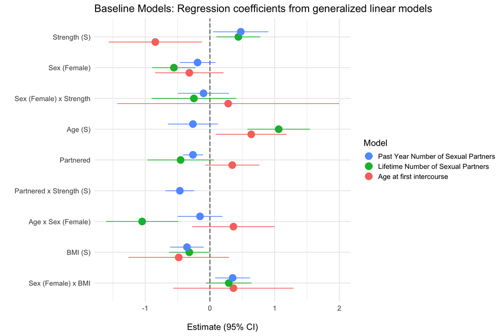

We also modeled current partnership status. While strength was a significant predictor of currently reporting being partnered, a sex and strength interaction emerged in the physical activity, and hormonal control models such that the strength effect was reduced for women.

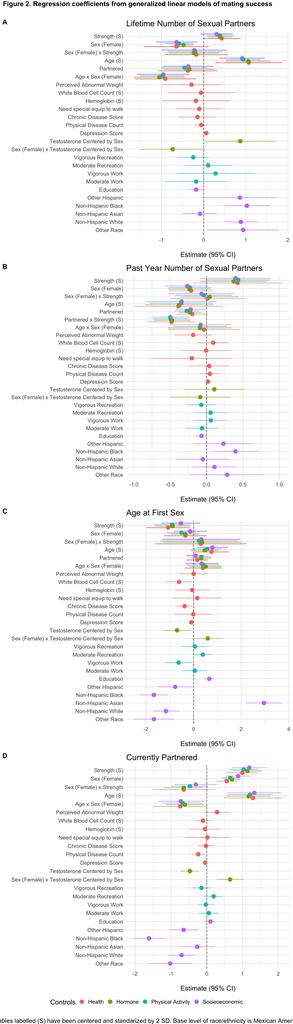

Lifetime number of partners control models

Standardized regression coefficents from generalized linear models

| **Characteristic** | Socioeconomic **log(IRR)**<sup>1</sup> | Socioeconomic **95% CI**<sup>1</sup> | Socioeconomic **p-value** | Health **log(IRR)**<sup>1</sup> | Health **95% CI**<sup>1</sup> | Health **p-value** | Hormone **log(IRR)**<sup>1</sup> | Hormone **95% CI**<sup>1</sup> | Hormone **p-value** | Physical Activity **log(IRR)**<sup>1</sup> | Physical Activity **95% CI**<sup>1</sup> | Physical Activity **p-value** |
| --- | --- | --- | --- | --- | --- | --- | --- | --- | --- | --- | --- | --- |
| age_centered | 0.91 | 0.37, 1.5 | 0.007 | 1.1 | 0.28, 1.9 | 0.020 | 1.1 | 0.51, 1.6 | 0.002 | 0.94 | 0.53, 1.4 | 0.001 |
| sex |  |  |  |  |  |  |  |  |  |  |  |  |
| male | — | — |  | — | — |  | — | — |  | — | — |  |
| female | -0.64 | -1.1, -0.16 | 0.019 | -0.64 | -1.4, 0.13 | 0.081 | -0.48 | -0.72, -0.23 | 0.002 | -0.58 | -0.93, -0.24 | 0.005 |
| strength_centered | 0.31 | -0.07, 0.68 | 0.091 | 0.43 | -0.02, 0.88 | 0.057 | 0.39 | 0.09, 0.68 | 0.016 | 0.39 | 0.06, 0.71 | 0.026 |
| partnered |  |  |  |  |  |  |  |  |  |  |  |  |
| FALSE | — | — |  | — | — |  | — | — |  | — | — |  |
| TRUE | -0.36 | -1.0, 0.24 | 0.2 | -0.38 | -1.1, 0.33 | 0.2 | -0.34 | -0.94, 0.27 | 0.2 | -0.45 | -1.0, 0.10 | 0.094 |
| edu | -0.18 | -0.33, -0.02 | 0.033 |  |  |  |  |  |  |  |  |  |
| race |  |  |  |  |  |  |  |  |  |  |  |  |
| MexicanAmerican | — | — |  |  |  |  |  |  |  |  |  |  |
| OtherHispanic | 0.86 | 0.00, 1.7 | 0.051 |  |  |  |  |  |  |  |  |  |
| NonHispanicWhite | 0.88 | 0.49, 1.3 | 0.002 |  |  |  |  |  |  |  |  |  |
| NonHispanicBlack | 1.0 | 0.48, 1.6 | 0.005 |  |  |  |  |  |  |  |  |  |
| NonHispanicAsian | -0.09 | -0.49, 0.31 | 0.6 |  |  |  |  |  |  |  |  |  |
| OtherRace | 0.94 | 0.09, 1.8 | 0.036 |  |  |  |  |  |  |  |  |  |
| age_centered * sex |  |  |  |  |  |  |  |  |  |  |  |  |
| age_centered * female | -1.0 | -1.6, -0.34 | 0.010 | -0.91 | -1.6, -0.18 | 0.025 | -1.0 | -1.7, -0.44 | 0.004 | -1.0 | -1.5, -0.46 | 0.003 |
| sex * strength_centered |  |  |  |  |  |  |  |  |  |  |  |  |
| female * strength_centered | -0.22 | -1.0, 0.56 | 0.5 | -0.17 | -0.92, 0.58 | 0.6 | -0.23 | -0.83, 0.37 | 0.4 | -0.20 | -0.85, 0.45 | 0.5 |
| perceived_abnormal_weight |  |  |  |  |  |  |  |  |  |  |  |  |
| FALSE |  |  |  | — | — |  |  |  |  |  |  |  |
| TRUE |  |  |  | -0.29 | -1.0, 0.42 | 0.3 |  |  |  |  |  |  |
| whitebloodcell_centered |  |  |  | -0.06 | -0.85, 0.72 | 0.8 |  |  |  |  |  |  |
| hemoglobin_centered |  |  |  | -0.18 | -1.0, 0.63 | 0.6 |  |  |  |  |  |  |
| special_equipment |  |  |  |  |  |  |  |  |  |  |  |  |
| FALSE |  |  |  | — | — |  |  |  |  |  |  |  |
| TRUE |  |  |  | -0.11 | -0.64, 0.43 | 0.6 |  |  |  |  |  |  |
| chronic_disease_score |  |  |  | -0.15 | -0.58, 0.29 | 0.4 |  |  |  |  |  |  |
| physical_disease_count |  |  |  | -0.06 | -0.21, 0.10 | 0.4 |  |  |  |  |  |  |
| depression |  |  |  | 0.06 | -0.02, 0.14 | 0.11 |  |  |  |  |  |  |
| testosterone_sex_centered |  |  |  |  |  |  | 0.87 | 0.02, 1.7 | 0.046 |  |  |  |
| sex * testosterone_sex_centered |  |  |  |  |  |  |  |  |  |  |  |  |
| female * testosterone_sex_centered |  |  |  |  |  |  | -0.74 | -1.5, 0.03 | 0.057 |  |  |  |
| vigorous_rec |  |  |  |  |  |  |  |  |  | -0.25 | -0.61, 0.12 | 0.2 |
| moderate_rec |  |  |  |  |  |  |  |  |  | 0.11 | -0.45, 0.66 | 0.7 |
| vigorous_work |  |  |  |  |  |  |  |  |  | 0.28 | -0.64, 1.2 | 0.5 |
| moderate_work |  |  |  |  |  |  |  |  |  | -0.18 | -0.90, 0.54 | 0.6 |

<sup>1</sup> IRR = Incidence Rate Ratio, CI = Confidence Interval

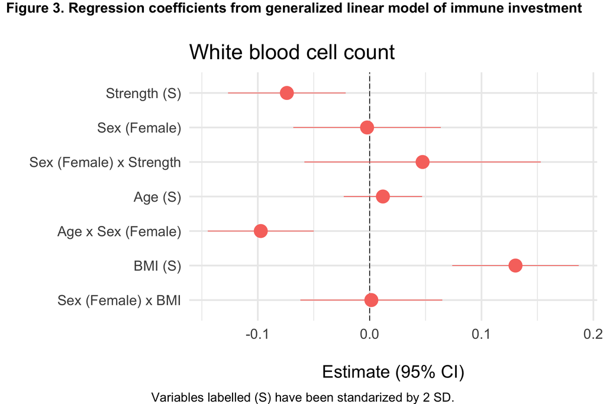

Regression coefficients for predictors of WBC count in men and women 18-59, exact model from lassek and gaulin

| **Variable** | **Beta (SE)**<sup>1,2</sup> |
| --- | --- |
| Age | 0.01 (0.016) |
| Sex |  |
| male | — |
| female | 0.00 (0.030) |
| Grip strength | -0.07* (0.024) |
| BMI | 0.13*** (0.025) |
| Age * Sex |  |
| Age * female | -0.10** (0.021) |
| Sex * Grip strength |  |
| female * Grip strength | 0.05 (0.047) |
| Sex * BMI |  |
| female * BMI | 0.00 (0.028) |

<sup>1</sup> *p<0.05; **p<0.01; ***p<0.001  
<sup>2</sup> SE = Standard Error

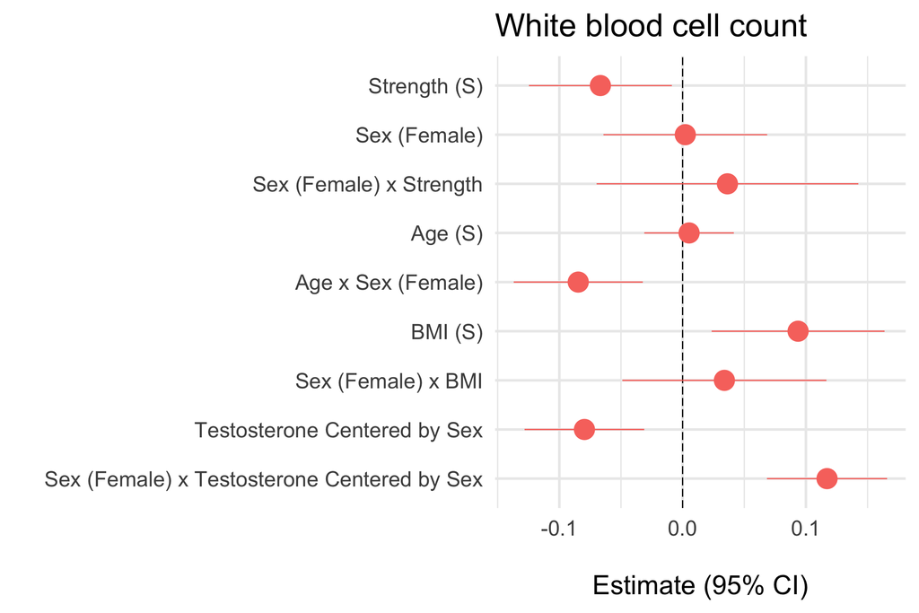

**Table 1. Participant Characteristics for all variables using population weights**

| **Variable** | **N** | **Sex** **male**, N = 88,509,275<sup>1</sup> | **Sex** **female**, N = 89,488,954<sup>1</sup> |
| --- | --- | --- | --- |
| Lifetime number of sexual partners | 154,788,464 | 22.17 (85.56) | 8.79 (21.30) |
| Missing |  | 9,399,242 | 13,810,524 |
| Past year number of sexual partners | 152,232,505 | 1.50 (2.88) | 1.10 (2.05) |
| Missing |  | 11,014,874 | 14,750,850 |
| Age at first sex (years) | 149,595,371 | 17.15 (3.90) | 17.45 (3.46) |
| Missing |  | 12,463,908 | 15,938,950 |
| Combined Grip Strength (kg) | 161,169,394 | 93.04 (17.11) | 59.20 (10.46) |
| Missing |  | 6,799,676 | 10,029,159 |
| Age (Years) | 177,998,229 | 38.93 (12.72) | 39.19 (12.31) |
| Partnered | 169,962,580 | 49,915,636 / 83,801,688 (60%) | 52,921,743 / 86,160,892 (61%) |
| Missing |  | 4,707,587 | 3,328,062 |
| Body mass index (kg/m^2) | 176,539,855 | 28.43 (6.06) | 28.82 (7.59) |
| Missing |  | 400,312 | 1,058,062 |
| Education | 177,998,229 |  |  |
| 1 |  | 4,341,291 / 88,509,275 (4.9%) | 3,675,364 / 89,488,954 (4.1%) |
| 2 |  | 11,428,131 / 88,509,275 (13%) | 9,190,348 / 89,488,954 (10%) |
| 3 |  | 20,044,761 / 88,509,275 (23%) | 15,849,989 / 89,488,954 (18%) |
| 4 |  | 27,925,804 / 88,509,275 (32%) | 31,390,266 / 89,488,954 (35%) |
| 5 |  | 24,769,288 / 88,509,275 (28%) | 29,382,988 / 89,488,954 (33%) |
| Race and Ethnicity | 177,998,229 |  |  |
| MexicanAmerican |  | 8,796,243 / 88,509,275 (9.9%) | 8,021,624 / 89,488,954 (9.0%) |
| OtherHispanic |  | 6,284,292 / 88,509,275 (7.1%) | 6,705,224 / 89,488,954 (7.5%) |
| NonHispanicWhite |  | 56,208,583 / 88,509,275 (64%) | 54,917,683 / 89,488,954 (61%) |
| NonHispanicBlack |  | 10,092,194 / 88,509,275 (11%) | 12,271,642 / 89,488,954 (14%) |
| NonHispanicAsian |  | 4,594,470 / 88,509,275 (5.2%) | 5,221,748 / 89,488,954 (5.8%) |
| OtherRace |  | 2,533,494 / 88,509,275 (2.9%) | 2,351,033 / 89,488,954 (2.6%) |
| White blood cell count (1000 cells/µL) | 171,390,380 | 6.94 (2.03) | 7.19 (2.09) |
| Missing |  | 3,522,973 | 3,084,876 |
| Hemoglobin (g/dL) | 171,390,380 | 15.12 (1.09) | 13.28 (1.16) |
| Missing |  | 3,522,973 | 3,084,876 |
| Depression Score (0-27) | 157,893,564 | 2.76 (4.13) | 3.51 (4.57) |
| Missing |  | 7,623,992 | 12,480,673 |
| Chronic Disease Score (0-6) | 168,873,214 | 0.40 (0.66) | 0.54 (0.82) |
| Missing |  | 5,306,808 | 3,818,207 |
| Disease Impairment Score (0-5) | 177,976,579 | 0.21 (0.69) | 0.27 (0.83) |
| Missing |  | 0 | 21,650 |
| Special equipment needed to walk | 169,940,930 | 2,534,447 / 83,801,688 (3.0%) | 3,945,778 / 86,139,242 (4.6%) |
| Missing |  | 4,707,587 | 3,349,712 |
| Perceived abnormal weight | 177,549,560 | 45,215,094 / 88,292,343 (51%) | 56,668,108 / 89,257,216 (63%) |
| Missing |  | 216,932 | 231,738 |
| Testosterone (ng/dL) | 165,955,614 | 410.86 (170.54) | 25.73 (23.25) |
| Missing |  | 5,834,154 | 6,208,460 |
| Work involves vigorous activity | 177,998,229 | 26,583,425 / 88,509,275 (30%) | 10,224,931 / 89,488,954 (11%) |
| Recreation involves vigorous activity | 177,998,229 | 32,548,398 / 88,509,275 (37%) | 22,240,837 / 89,488,954 (25%) |
| Work involves moderate activity | 177,998,229 | 37,490,844 / 88,509,275 (42%) | 28,878,167 / 89,488,954 (32%) |
| Recreation involves moderate activity | 177,998,229 | 42,706,882 / 88,509,275 (48%) | 44,981,890 / 89,488,954 (50%) |

<sup>1</sup> Mean (SD); n / N (%)

## 4. Confirmatory Analysis

### 4.1 Method

### Discussion

Under what conditions would we still expect sexual dimorphism in strength even when it is positively associated with reproductive success for both males and females?

Association between strength and fitness for women